# Homework 2 Solutions

## Question 1

```r
glimpse(drosophila)
```

```
## Rows: 1,372
## Columns: 8
## $ Generation  <chr> "F0", "F0", "F0", "F0", "F0", "F0", "F0", "F0", "F0", "F0"…
## $ Vial        <chr> "1", "6", "1", "8", "4", "4", "7", "5", "10", "10", "10", …
## $ Diet        <chr> "poor", "poor", "poor", "poor", "poor", "poor", "poor", "p…
## $ DietHistory <chr> "P", "P", "P", "P", "P", "P", "P", "P", "P", "P", "P", "S"…
## $ Mass        <dbl> 0.8, 0.9, 0.9, 0.9, 1.5, 0.9, 1.1, 1.0, 0.9, 0.8, 0.6, 1.4…
## $ WingLength  <dbl> 1.431, 1.477, 1.514, 1.531, 1.535, 1.575, 1.578, 1.618, 1.…
## $ LarvalTime  <dbl> 7.5, 7.5, 7.5, 9.5, 7.5, 7.5, 7.5, 6.5, 6.5, 7.5, 8.5, 5.5…
## $ PupalTime   <dbl> 4, 4, 4, 4, 4, 4, 4, 4, 4, 3, 4, 4, 4, 5, 4, 4, 4, 4, 4, 5…
```

```r
drosophila %>%
  drop_na() %>%
  glimpse()
```

```
## Rows: 1,372
## Columns: 8
## $ Generation  <chr> "F0", "F0", "F0", "F0", "F0", "F0", "F0", "F0", "F0", "F0"…
## $ Vial        <chr> "1", "6", "1", "8", "4", "4", "7", "5", "10", "10", "10", …
## $ Diet        <chr> "poor", "poor", "poor", "poor", "poor", "poor", "poor", "p…
## $ DietHistory <chr> "P", "P", "P", "P", "P", "P", "P", "P", "P", "P", "P", "S"…
## $ Mass        <dbl> 0.8, 0.9, 0.9, 0.9, 1.5, 0.9, 1.1, 1.0, 0.9, 0.8, 0.6, 1.4…
## $ WingLength  <dbl> 1.431, 1.477, 1.514, 1.531, 1.535, 1.575, 1.578, 1.618, 1.…
## $ LarvalTime  <dbl> 7.5, 7.5, 7.5, 9.5, 7.5, 7.5, 7.5, 6.5, 6.5, 7.5, 8.5, 5.5…
## $ PupalTime   <dbl> 4, 4, 4, 4, 4, 4, 4, 4, 4, 3, 4, 4, 4, 5, 4, 4, 4, 4, 4, 5…
```

The `drosophila` data were collected by researchers interested in studying whether non-genetic traits can be passed down to offspring. The data were made available in the paper ‘Ancestral and offspring nutrition interact to affect life-history traits in Drosophila melanogaster’ (Deas et al. 2018, *Proc. R. Soc. B.*), and contain 1372 rows. Each row represents one fruit fly, and there are 8 variables recorded for each fly. These variables capture information about the experiment (such as which generation the fly was in, and the diet of that fly and its ancestors), as well as measurements on the fly’s development, like mass (in mg) and larval time (in days). There are no missing values in the data.

**Grading**:

When grading this question, please comment on any parts which are missing or incorrect.

- 10/10: each component is present and most are correct, and code for answering the question is included. (The answer can be written in bullet points or a list, it does not have to be in a paragraph for this assignment).
- 7/10: each component is present and most are correct, but code is not included.
- 7/10: code is included, but one or two components are missing
- 4/10: 3 or more components are missing, OR code is missing and one or more components is missing
- 0/10: no answer

## Question 2

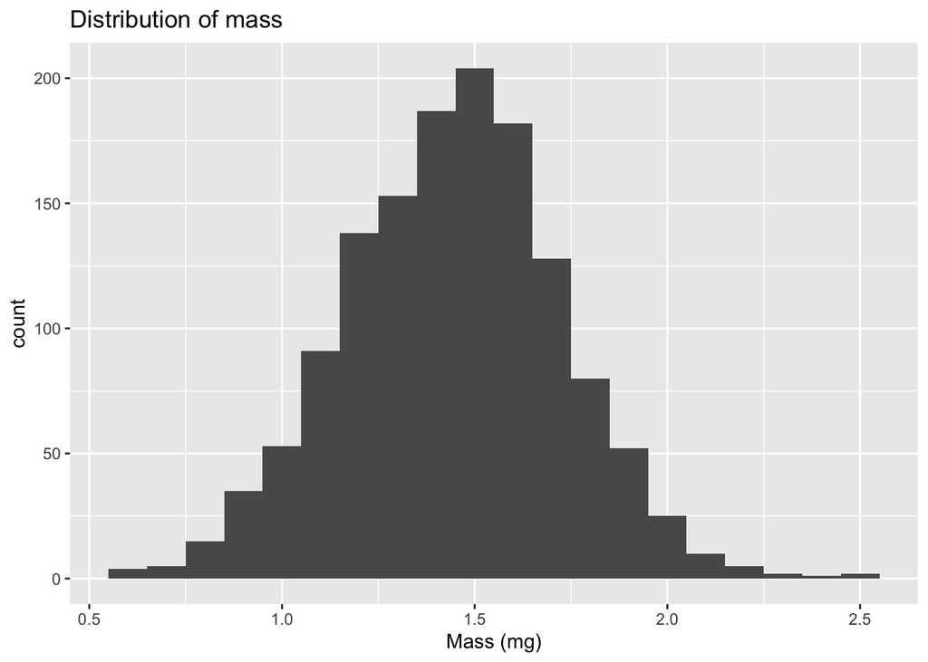

```r
drosophila %>%
  ggplot(aes(x = Mass)) +
  geom_histogram(bins=20) +
  labs(x = "Mass (mg)",
       title = "Distribution of mass")
```

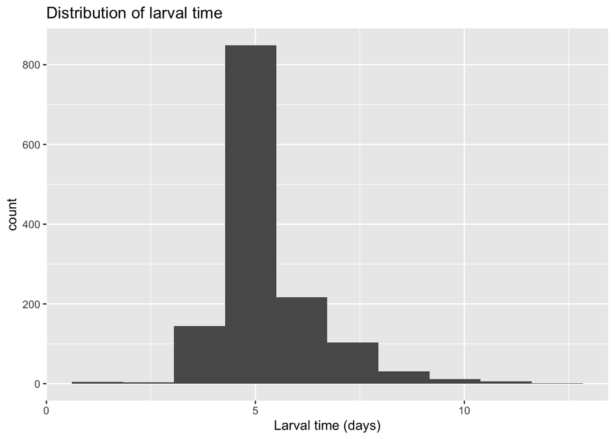

```r
drosophila %>%
  ggplot(aes(x = LarvalTime)) +
  geom_histogram(bins=10) +
  labs(x = "Larval time (days)",
       title = "Distribution of larval time")
```

```r
drosophila %>%
  summarize(mean_mass = mean(Mass),
            sd_mass = sd(Mass),
            mean_larval = mean(LarvalTime),
            sd_larval = sd(LarvalTime))
```

```
## # A tibble: 1 × 4
##   mean_mass sd_mass mean_larval sd_larval
##       <dbl>   <dbl>       <dbl>     <dbl>
## 1      1.44   0.282        5.48      1.30
```

The distribution of mass is unimodal and symmetric, with a mean of 1.44 mg and a standard deviation of 0.282 mg. There do not appear to be any outliers. As we experiment with different numbers of bins, we notice that mass only takes on discrete values in the data: 1.0, 1.1, 1.2, etc.

The distribution of larval time is unimodal and somewhat right-skewed, with a mean of 5.48 days and a standard deviation of 1.3 days. There may be a couple outliers with larval times around 11 days. As with mass, we notice that larval time only takes on a few discrete values. This may be the result of how the data is measured – if the researchers only check the flies once a day, they cannot measure larval time more precisely.

**Grading:**

To get full credit, they need to include full code, and comment on each aspect of each distribution (center, shape, spread, unusual features, outliers). Acceptable plots for the distribution are histogram, density plot, or violin plot. If they make a boxplot, they can get partial credit (but boxplots don’t answer questions about modality, e.g.)

- 10/10: the correct plots and summary statistics are made, code is included, and correct descriptions of each aspect.
- 7/10: Correct plots (or boxplot) and summary statistics are made, code is included, mostly correct descriptions.
- 5/10: Code and/or plots are not included, but mostly correct descriptions
- 3/10: Incorrect plots and/or descriptions
- 0/10: no answer

## Question 3

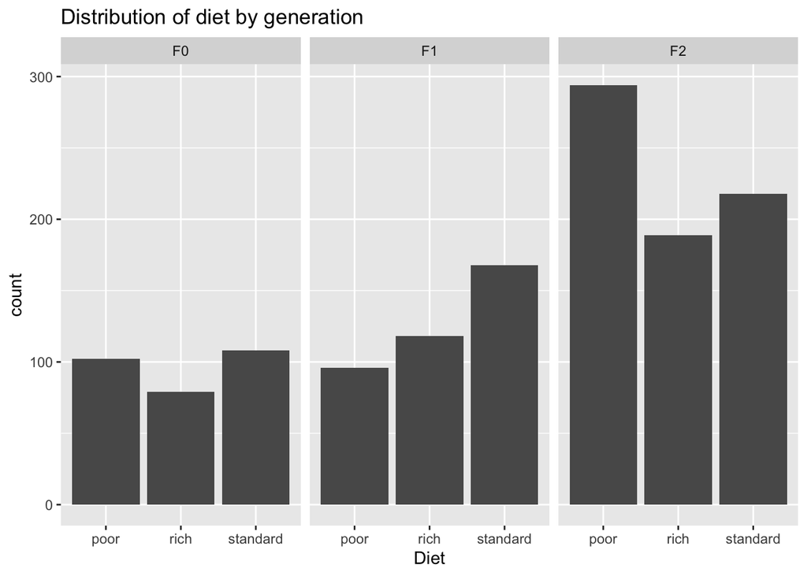

```r
drosophila %>%
  ggplot(aes(x = Diet)) +
  geom_bar() +
  facet_wrap(~Generation) +
  labs(title = "Distribution of diet by generation")
```

**Grading:**

- 10/10: the correct plot, code is included, correct answer.
- 7/10: Correct plot, code is included, mostly correct answer
- 5/10: Code and/or plot not included or incorrect, mostly correct answer
- 3/10: Code and/or plot included, answer missing
- 0/10: everythig missing

## Question 4

```r
drosophila %>%
  select(Generation, DietHistory) %>%
  arrange(Generation) %>%
  distinct()
```

```
## # A tibble: 25 × 2
##    Generation DietHistory
##    <chr>      <chr>
##  1 F0         P
##  2 F0         S
##  3 F0         R
##  4 F1         PP
##  5 F1         RP
##  6 F1         PR
##  7 F1         RS
##  8 F1         SS
##  9 F1         PS
## 10 F1         RR
## # … with 15 more rows
```

All three diet histories are present in F0. In F1 and F2, some diet histories are missing – two from F1 (SP and SR), and 12 from F2. The diet histories missing from F2 appear to be ones involving the standard diet – SPx and SRx are missing because SP and SR were missing in F1, and not all F1 standard groups appear to have been bred for all F2 diets (e.g., RSP is missing).

**Grading:**

There are many different ways of figuring out which diet histories are missing. Any of them are valid.

- 10/10: Useful code, correct answer.
- 7/10: Useful code, mostly correct answer
- 5/10: Either code not included, or answer not included
- 0/10: everything missing

## Question 5

```r
drosophila %>%
  group_by(Generation, Diet) %>%
  summarize(mean_mass = mean(Mass),
            mean_larval = mean(LarvalTime))
```

```
## # A tibble: 9 × 4
## # Groups:   Generation [3]
##   Generation Diet     mean_mass mean_larval
##   <chr>      <chr>        <dbl>       <dbl>
## 1 F0         poor          1.22        7.16
## 2 F0         rich          1.71        4.07
## 3 F0         standard      1.60        5.37
## 4 F1         poor          1.17        7.36
## 5 F1         rich          1.64        4.19
## 6 F1         standard      1.50        5.46
## 7 F2         poor          1.24        6.11
## 8 F2         rich          1.57        4.11
## 9 F2         standard      1.51        5.48
```

Average mass and larval time appear to be negatively related, with higher average mass associated with lower average larval time (quicker development). The relationship appears to hold across generations.

**Grading:**

- 10/10: correct statistics are calculated (with correct grouping), code included, and correct interpretation in written answer
- 7/10: correct statistics calculated, code included, some errors in written answer
- 5/10: Code not included or wrong, some errors in written answer
- 3/10: Code included, no interpretation
- 0/10: everything missing

## Question 6

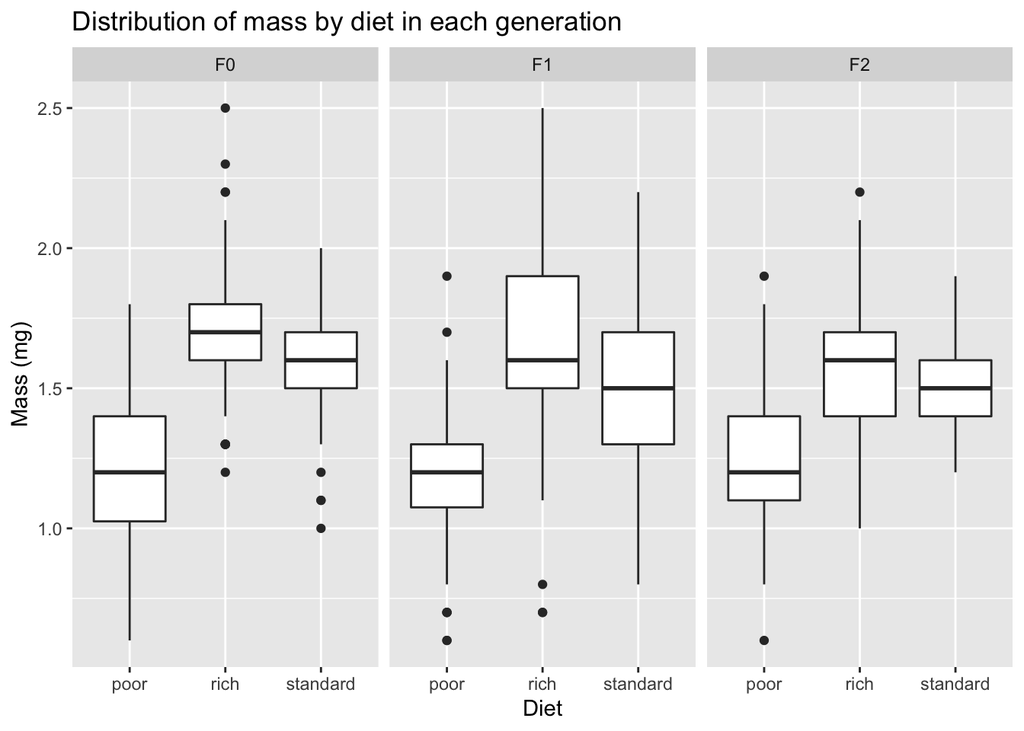

```r
drosophila %>%
  ggplot(aes(x = Diet, y = Mass)) +
  geom_boxplot() +
  facet_wrap(~Generation) +
  labs(x = "Diet",
       y = "Mass (mg)",
       title = "Distribution of mass by diet in each generation")
```

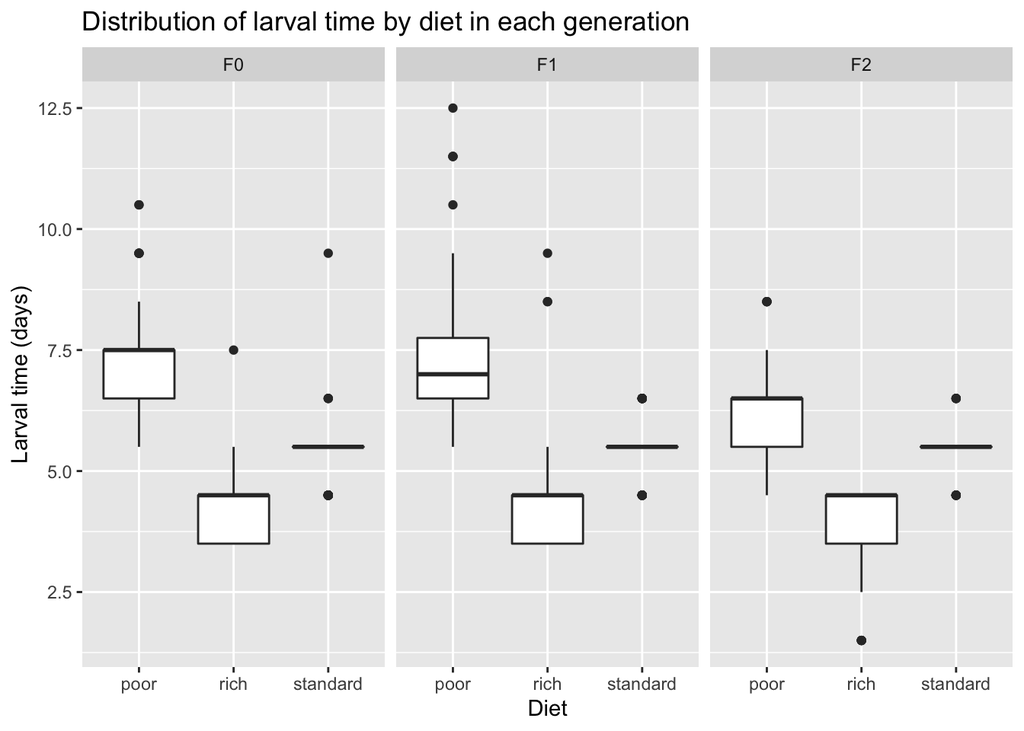

```r
drosophila %>%
  ggplot(aes(x = Diet, y = LarvalTime)) +
  geom_boxplot() +
  facet_wrap(~Generation) +
  labs(x = "Diet",
       y = "Larval time (days)",
       title = "Distribution of larval time by diet in each generation")
```

**Grading:**

The question asks them to create a plot, but doesn’t specify boxplots. As long as they create a readable plot that allows them to answer the question, it doesn’t have to be boxplots (e.g., faceting histograms by both diet and generation are acceptable, as are violin plots instead of boxplots). However, some students may make plots which display the correct variables, but are really hard to read – e.g., overlapping histograms colored by diet, or scatterplots instead of boxplots. If the plot shows the correct variables but is hard to read, they will lose some points.

- 10/10: useful plots, code is included.
- 7/10: Plots show the correct variables but are hard to read, code is included
- 4/10: Plots show mix of correct and incorrect variables
- 0/10: missing, or completely wrong plots

## Question 7

Diet does appear to be associated with differences in development. We can see that flies with poor diets tend to have smaller mass and take longer to develop, compared to flies with righ or standard diets. This relationship holds across generations.

**Grading:**

The correct answer compares the distribution of mass and larval time between the different diets, within each generation.

- 10/10: correct answer, with justification
- 7/10: Correct answer, missing some justification
- 4/10: Incorrect answer, attempt at justification
- 0/10: no answer, or completely incorrect with no justification

## Question 8

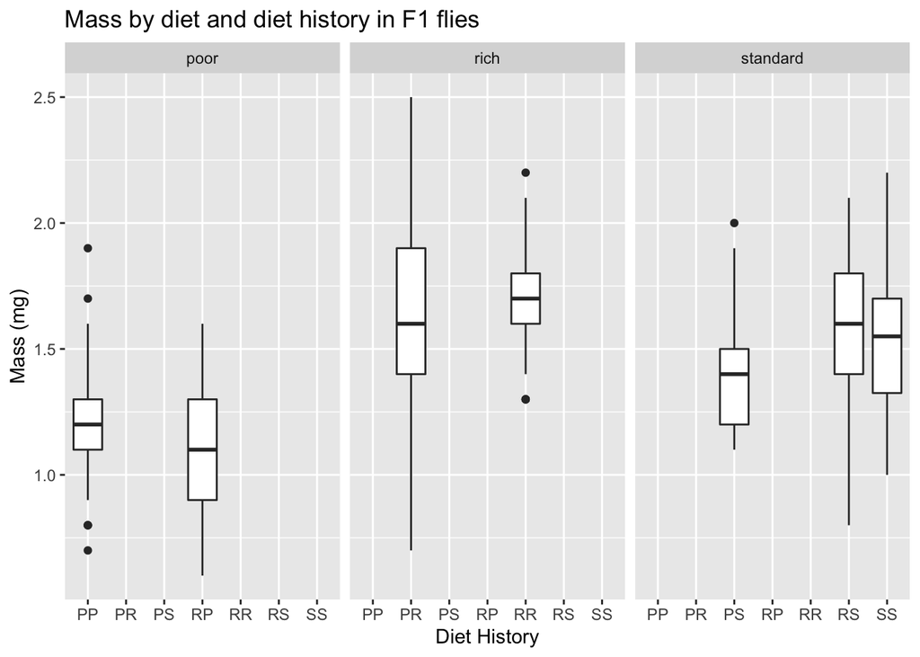

```r
drosophila %>%
  filter(Generation == "F1") %>%
  ggplot(aes(x = DietHistory, y = Mass)) +
  geom_boxplot() +
  facet_wrap(~Diet) +
  labs(x = "Diet History",
       y = "Mass (mg)",
       title = "Mass by diet and diet history in F1 flies")
```

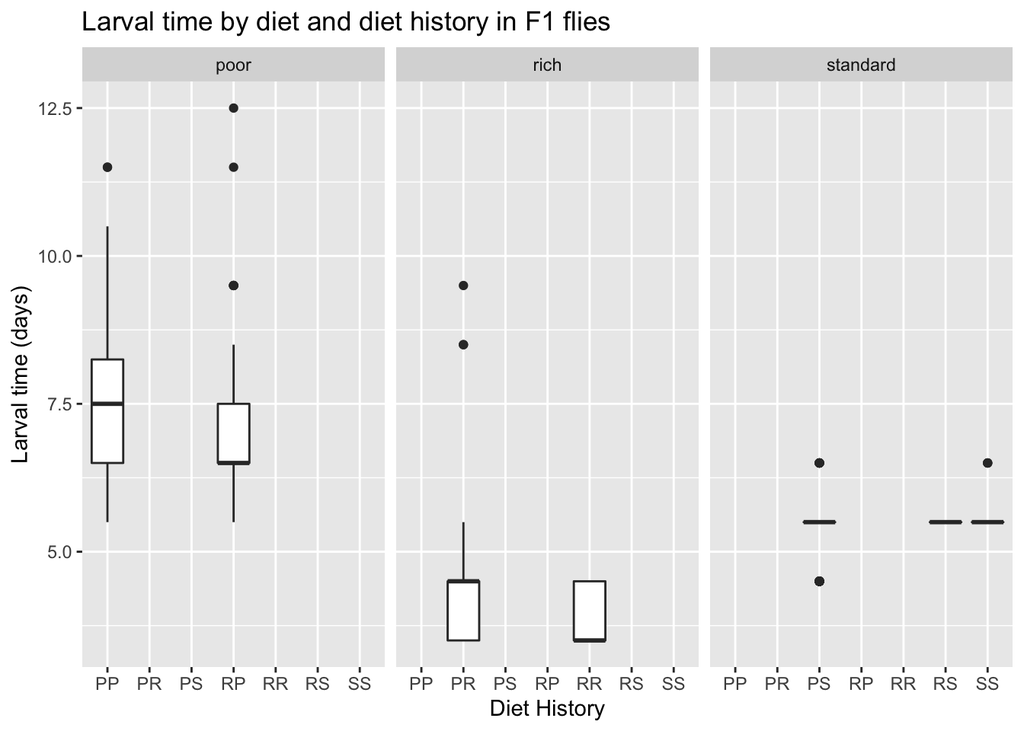

```r
drosophila %>%
  filter(Generation == "F1") %>%
  ggplot(aes(x = DietHistory, y = LarvalTime)) +
  geom_boxplot() +
  facet_wrap(~Diet) +
  labs(x = "Diet History",
       y = "Larval time (days)",
       title = "Larval time by diet and diet history in F1 flies")
```

**Grading:**

The question asks them to create a plot, but doesn’t specify boxplots. As long as they create a readable plot that allows them to answer the question, it doesn’t have to be boxplots (e.g., faceting histograms by both diet history and diet are acceptable, as are violin plots instead of boxplots). However, some students may make plots which display the correct variables, but are really hard to read – e.g., overlapping histograms colored by diet history, or scatterplots instead of boxplots. If the plot shows the correct variables but is hard to read, they will lose some points.

- 10/10: useful plots, code is included.
- 7/10: Plots show the correct variables but are hard to read, code is included
- 4/10: Plots show mix of correct and incorrect variables
- 0/10: missing, or completely wrong plots

## Question 9

There may be some association between diet history and fruit fly development, after conditioning on diet. Examining F1 flies with rich diets, we can see that those whose parents had rich diets tend to have slightly higher mass than those whose parents had poor diets. Similarly, for F1 flies with standard diets, those whose parents had poor diets tend to have somewhat lower mass. Likewise, RR flies tend to have shorter development times than PR flies, and RP flies tend to have shorter development times than PP flies. However, if there is a relationship between diet history and fruit fly development, the effect is not as large as the association between diet and fruit fly development.

**Grading:**

The correct answer compares the distribution of mass and larval time between the different diet histories, within each diet.

- 10/10: correct answer, with justification
- 7/10: Correct answer, missing some justification
- 4/10: Incorrect answer, attempt at justification
- 0/10: no answer, or completely incorrect with no justification

## Question 10

- *Data matching:* 10 We are interested in assessing the relationships between diet, diet history and fruit fly development, and the data directly measure these variables. Furthermore, since the data come from a randomized experiment, we don’t need to worry about other variables which might be associated with both diet history and fly development.
- *Exhaustive:* 5 There is some exhaustiveness, as both summary statistics and plots were used to investigate the research question.
- *Skeptical:* 3 There is a little skepticism, with fly development measured by two different variables. However, only diet and diet history are considered as predictors, with no alternative explanations considered. (Note that in this case – a randomized experiment – skepticism is not necessary for the analysis).
- *Second-order:* 1 There aren’t really any second order details in the analysis done in the homework questions. Second-order context is provided in the introduction to the assignment, but not in the exercises themselves.
- *Transparency:* 10 The analysis depends entirely on a few visualizations and summary statistics, and so is very transparent.
- *Reproducibility:* 10 The analysis is very reproducible – the data is publicly available from the research paper, which also describes the experimental design and data collection process. The analysis completed here includes all code.

**Grading:**

Since I provided the transparency section, there are 5 principles they need to analyze, and they get 2 points per principle. They don’t have to get exactly the same number or answer as me, but their response should roughly agree with what I have written to get credit for a principle.

- 10/10: all 5 remaining principles
- 8/10: 4 principles
- 6/10: 3 principles
- 4/10: 2 principles
- 2/10: 1 principles
- 0/10: no answer